# Sex-aware Post-impute Quality Control Pipeline Using GXwasR

## Step 18: Sex-specific sample level QC

For this, we will use QCsample().

```
## [1] "Program is set up."
## [1] "Plots are initiated."
```

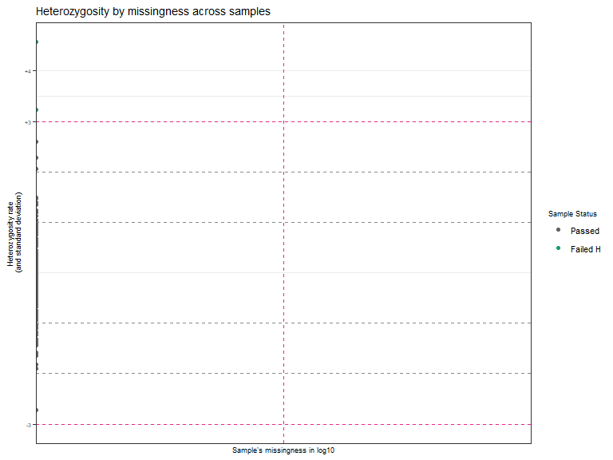

```
## [1] "No. of samples filtered/flagged for missingness: 0"
## [1] "No. of samples filtered/flagged for heterozygosity threshold: 2"
## [1] "No. of samples filtered/flagged for missingness and heterozygosity: 2"
## [1] "No sample is filtered out for IDB after missingness and heterozygosity filter."
## [1] "No. of samples in input plink files: 151"
## [1] "No. of samples in output plink files: 149"
## [1] "Output plink files, Postimpute_Female1 with final samples are in C:\\Users\\Sarah\\AppData\\Local\\Temp\\RtmpwLdgcn."
```

```r
## Running the function female-specific QC
finput <- "Postimpute_Female"
foutput <- "Postimpute_Female1"
imiss = 0.02
#Since het = 3 was removing a lot of samples (185), I decided to increase the threshold after looking at the plot.
het = 3
small_sample_mod = TRUE
IBD = 0.2
x = QCsample(DataDir = DataDir,ResultDir = ResultDir, finput = finput,foutput = foutput, imiss = imiss,het = het, small_sample_mod = small_sample_mod, IBD = IBD)
```

```
## [1] "Program is set up."
## [1] "Plots are initiated."
```

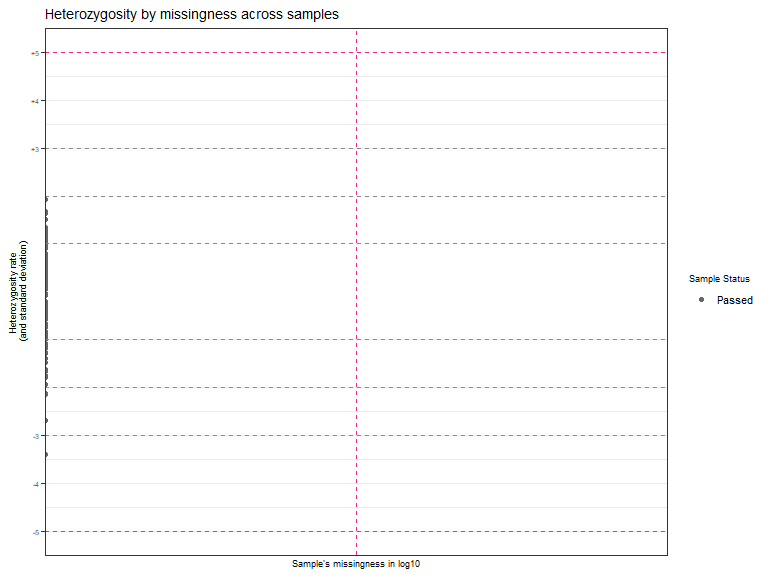

```
## [1] "No. of samples filtered/flagged for missingness: 0"
## [1] "No. of samples filtered/flagged for heterozygosity: 0"
## [1] "No. of samples filtered for missingness and heterozygosity: 0"
## [1] "No sample is filtered out for IDB after missingness and heterozygosity filter."
## [1] "No. of samples in input plink files: 125"
## [1] "No. of samples in output plink files: 125"
## [1] "Output plink files, Postimpute_Male1 with final samples are in C:\\Users\\Sarah\\AppData\\Local\\Temp\\RtmpwLdgcn."
```

```r
## Running the function male-specific QC

finput <- "Postimpute_Male"
foutput <- "Postimpute_Male1"
imiss = 0.02
#Since het = 3 was removing a lot of samples (185), I decided to increase the threshold after looking at the plot.
het = 5
small_sample_mod = TRUE
IBD = 0.2
x = QCsample(DataDir = DataDir,ResultDir = ResultDir, small_sample_mod = small_sample_mod, finput = finput,foutput = foutput, imiss = imiss,het = het, IBD = IBD)
```

```r
## Copying filtered plink files to DataDir
ftemp <- list.files(paste0(ResultDir,"/"),pattern = "Postimpute_")
invisible(file.copy(paste0(ResultDir,"/",ftemp),DataDir))
invisible(file.remove(paste0(ResultDir,"/",ftemp)))
```

## Step 19: Combine male and female-specific Qc-ed genotype datasets

```r
## Combine male and female-specific files
## Running the function
finput1 <- "Postimpute_Female1"
finput2 <- "Postimpute_Male1"
foutput <- "PostimputeFinal"
y <- MergeRegion(DataDir, ResultDir, finput1, finput2, foutput, use_common_snps = TRUE)
```

```
## [1] "Program is set up."
## [1] "Merging is done using the common SNPs between the input genotype files."
## [1] "Plink files with merged regions are in C:\\Users\\Sarah\\AppData\\Local\\Temp\\RtmpwLdgcn prefixed as PostimputeFinal"
```

```r
## Removing the not needed files from DataDir.
ftemp <- list.files(paste0(DataDir,"/"),pattern = "Postimpute_")
invisible(file.remove(paste0(DataDir,"/",ftemp)))
```

## Final Summary of the final QC-ed genotype dataset

```r
finput <- "PostimputeFinal"
x <- PlinkSummary(ResultDir, ResultDir, finput)
```

```
## [1] "Program is set up."
## [1] "Dataset:PostimputeFinal"
## [1] "Number of missing phenotypes:0"
## [1] "Number of males:125"
## [1] "Number of females:149"
## [1] "This is a case-control data."
## [1] "Number of cases:107"
## [1] "Number of controls:167"
## [1] "Number of cases in males:53"
## [1] "Number of controls in males:72"
## [1] "Number of cases in females:54"
## [1] "Number of controls in females:95"
## [1] "Number of chromosomes:11"
##  [1] "Chr:1"  "Chr:2"  "Chr:3"  "Chr:4"  "Chr:5"  "Chr:6"  "Chr:7"  "Chr:8"
##  [9] "Chr:9"  "Chr:10" "Chr:23"
## [1] "Total number of SNPs:16208"
## [1] "Total number of samples:274"
```

## Citation

If you are using GXwasR package and/or following this pipeline in your study, please cite it as:

```r
citation("GXwasR")
```

[output not shown]

## Tutorials Link (These will be available with the publications.)

**Please follow these tutorials to know more about the functionality of the package GXwasR.**

A list of all the functions in GXwasR:

Tutorial for performing post-imputation QC followed by sex-aware association tests:

Tutorial for performing pre-imputation QC using GXwasR:

Tutorial for performing post-imputation QC using GXwasR:

Tutorial for ancestry estimation:

Tutorial for meta analysis:

Tutorial for heritability estimate and genetic correlation:

Tutorial for gene-based tests:

```
                              ******************* THANK YOU! *************************
```